# Rompietti_2025_bulkRNA-seq_analysis

Author

Pakorn Sagulkoo

In this code, we will analyse mouse bulk RNA-seq from [Rompietti et al. (2025)](https://www.nature.com/articles/s41375-025-02557-y). This study employed a mouse experimental model in which a CLL- and RT-like condition was induced using Eμ-*TCL1 Bcor<sup>-/-</sup>* mice model. We will analyse the gene expression from the count matrices from original article.

# Import the relevant packages and set working path directory

```r
# Import the relavant packages
library(ensembldb)
library(biomaRt)
library(dplyr)
library(tibble)
library(stringr)
library(ggplot2)
library(ggrepel)
```

```r
# Check root path
here::here()
```

```
[1] "/mnt/hp-storage/users/pakorns"
```

# Define paths

```r
# Define paths to load and save files
path_to_samples <- here::here("RNAseq/Rompietti_2025")
path_to_ref_transcriptome <- "/home/pakorns/hc-storage/fastq_files/RNAseq/transcriptome_ref"
path_to_save_dea <- here::here("RNAseq/systematic_review/3-Rompietti_2025/expression_data/Rompietti_dea.rds")
path_to_save_hm_gsea <- here::here("RNAseq/systematic_review/3-Rompietti_2025/enrichment_data/Rompietti_hm_gsea.rds")
path_to_save_go_gsea <- here::here("RNAseq/systematic_review/3-Rompietti_2025/enrichment_data/Rompietti_go_gsea.rds")
path_to_save_kegg_gsea <- here::here("RNAseq/systematic_review/3-Rompietti_2025/enrichment_data/Rompietti_kegg_gsea.rds")
path_to_save_reactome_gsea <- here::here("RNAseq/systematic_review/3-Rompietti_2025/enrichment_data/Rompietti_reactome_gsea.rds")
path_to_save_wikipath_gsea <- here::here("RNAseq/systematic_review/3-Rompietti_2025/enrichment_data/Rompietti_wikipath_gsea.rds")
```

# Load data and functions

```r
# Source functions
source(here::here("bin/utils.R"))
```

```r
# List the files and paths
sample_list <- c("TCL1", "TCL2", "TCL3", "TCL1BCOR1", "TCL1BCOR2", "TCL1BCOR3")
path_to_download <- str_c(path_to_samples, "/", sample_list, ".counts.txt")
names(path_to_download) <- sample_list
path_to_download
```

```
                                                                      TCL1
     "/mnt/hp-storage/users/pakorns/RNAseq/Rompietti_2025/TCL1.counts.txt"
                                                                      TCL2
     "/mnt/hp-storage/users/pakorns/RNAseq/Rompietti_2025/TCL2.counts.txt"
                                                                      TCL3
     "/mnt/hp-storage/users/pakorns/RNAseq/Rompietti_2025/TCL3.counts.txt"
                                                                 TCL1BCOR1
"/mnt/hp-storage/users/pakorns/RNAseq/Rompietti_2025/TCL1BCOR1.counts.txt"
                                                                 TCL1BCOR2
"/mnt/hp-storage/users/pakorns/RNAseq/Rompietti_2025/TCL1BCOR2.counts.txt"
                                                                 TCL1BCOR3
"/mnt/hp-storage/users/pakorns/RNAseq/Rompietti_2025/TCL1BCOR3.counts.txt"
```

# Construct an expression matrix

```r
# Read some table to explore their structures
examp_expr.df <- read.table(path_to_download[[1]], header = TRUE)
head(examp_expr.df)
```

```
              Geneid           Chr
1 ENSMUSG00000102693             1
2 ENSMUSG00000064842             1
3 ENSMUSG00000051951 1;1;1;1;1;1;1
4 ENSMUSG00000102851             1
5 ENSMUSG00000103377             1
6 ENSMUSG00000104017             1
                                                    Start
1                                                 3073253
2                                                 3102016
3 3205901;3206523;3213439;3213609;3214482;3421702;3670552
4                                                 3252757
5                                                 3365731
6                                                 3375556
                                                      End        Strand Length
1                                                 3074322             +   1070
2                                                 3102125             +    110
3 3207317;3207317;3215632;3216344;3216968;3421901;3671498 -;-;-;-;-;-;-   6094
4                                                 3253236             +    480
5                                                 3368549             -   2819
6                                                 3377788             -   2233
  TCL1
1    0
2    0
3    0
4    0
5    0
6    0
```

We can see that the transcript ids were alreadey converted to gene id and the count values is the last column (naming `TCL1`). We will extract Geneid and TCL1 column and do the same thing as other datasets and then merge them all.

```r
# Create a list to collect expression dataframes
expr_df.lst <- purrr::map2(path_to_download, sample_list, function(path, sample){
  df <- read.table(path, header = TRUE)
  df <- df %>%
    dplyr::select(Geneid, sample)
  return(df)
})
names(expr_df.lst) <- sample_list
```

```r
# Join the dataframe
expr.df <- purrr::reduce(expr_df.lst, full_join, by = "Geneid")
head(expr.df)
```

```
              Geneid TCL1 TCL2 TCL3 TCL1BCOR1 TCL1BCOR2 TCL1BCOR3
1 ENSMUSG00000102693    0    0    0         0         0         0
2 ENSMUSG00000064842    0    0    0         0         0         0
3 ENSMUSG00000051951    0    0    0         0         0         0
4 ENSMUSG00000102851    0    0    0         0         0         0
5 ENSMUSG00000103377    0    0    0         0         0         0
6 ENSMUSG00000104017    0    0    0         0         0         0
```

```r
# Construct an expression matrix
expr_mat <- expr.df %>%
  column_to_rownames("Geneid") %>%
  as.matrix()
head(expr_mat)
```

```
                   TCL1 TCL2 TCL3 TCL1BCOR1 TCL1BCOR2 TCL1BCOR3
ENSMUSG00000102693    0    0    0         0         0         0
ENSMUSG00000064842    0    0    0         0         0         0
ENSMUSG00000051951    0    0    0         0         0         0
ENSMUSG00000102851    0    0    0         0         0         0
ENSMUSG00000103377    0    0    0         0         0         0
ENSMUSG00000104017    0    0    0         0         0         0
```

# Transcriptomics analysis using DESeq2

```r
# Import the relevant package
library(DESeq2)
library(limma)
```

## Create a DESeq2 object

```r
# Create metadata for DESeq2 object
colData <- data.frame(samples = sample_list)
colData$condition <- ifelse(grepl("BCOR", colData$samples), "RT", "CLL")
rownames(colData) <- colData$samples
colData$condition <- factor(colData$condition)
colData
```

```
            samples condition
TCL1           TCL1       CLL
TCL2           TCL2       CLL
TCL3           TCL3       CLL
TCL1BCOR1 TCL1BCOR1        RT
TCL1BCOR2 TCL1BCOR2        RT
TCL1BCOR3 TCL1BCOR3        RT
```

```r
# Create the object
dds <- DESeqDataSetFromMatrix(expr_mat, colData, ~ condition)
```

```r
# Keep genes with at least 10 counts across all samples
keep <- rowSums(counts(dds)) >= 10
dds <- dds[keep,]

# Run DESeq2
dds$condition <- relevel(dds$condition, ref = "CLL")
dds <- DESeq(dds)
```

## Plot the PCA based on the expression data

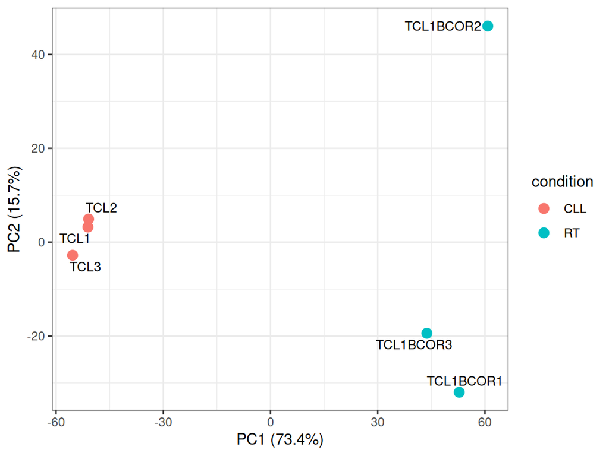

```r
# Variance stabilised transformation
vsdata <- vst(dds, blind = FALSE)

# Extract matrix
vs_mat <- assay(vsdata)

# Adjust for batch (assume batch info is in colData(dds)$batch)
vs_mat_corrected <- removeBatchEffect(vs_mat, batch = colData(dds)$batch)

# PCA on corrected data
pca <- prcomp(t(vs_mat_corrected))

# Calculate % variance explained
pca_var <- pca$sdev^2               # variance of each PC
pca_var_percent <- pca_var / sum(pca_var) * 100

# Create case name
case <- sub("^0*", "", sub("-.*$", "", rownames(colData(dds))))

# Make a dataframe for ggplot
pca_df <- data.frame(pca$x,
                     condition = colData(dds)$condition,
                     sample = case)

# Plot
pca.plt <- ggplot(pca_df, aes(PC1, PC2, color=condition, label=sample)) +
  geom_point(size = 3) +
  geom_text_repel(size=3.25, color = "black") +
  xlab(paste0("PC1 (", round(pca_var_percent[1], 1), "%)")) +
  ylab(paste0("PC2 (", round(pca_var_percent[2], 1), "%)")) +
  theme_bw()

pca.plt
```

After batch correction using `limma()`, we can see that the samples were grouped based on the conditions.

## Differential gene expression analysis

```r
# Generate a table for gene expression
res <- lfcShrink(dds,
                 contrast = c("condition", "RT", "CLL"),
                 type = 'normal')
head(res)
```

```
log2 fold change (MAP): condition RT vs CLL
Wald test p-value: condition RT vs CLL
DataFrame with 6 rows and 6 columns
                     baseMean log2FoldChange     lfcSE      stat      pvalue
                    <numeric>      <numeric> <numeric> <numeric>   <numeric>
ENSMUSG00000098104   11.74205       0.140751  0.598401  0.235781 0.813602384
ENSMUSG00000103922    2.69909       0.573032  0.877227  0.653363 0.513522359
ENSMUSG00000033845  809.57479       0.264786  0.204638  1.293916 0.195694330
ENSMUSG00000102275   13.43089       0.272586  0.523359  0.520930 0.602415566
ENSMUSG00000025903  770.49414       0.644033  0.286112  2.251014 0.024384622
ENSMUSG00000033813 2080.10204       0.719004  0.217475  3.306147 0.000945884
                        padj
                   <numeric>
ENSMUSG00000098104 0.8925833
ENSMUSG00000103922 0.6790906
ENSMUSG00000033845 0.3581252
ENSMUSG00000102275 0.7478355
ENSMUSG00000025903 0.0746579
ENSMUSG00000033813 0.0050626
```

## Convert mouse to human ensemble ids

```r
# Get orthologs
path_to_ortholog <- str_c(path_to_ref_transcriptome, "/mouse_human_ortholog.txt")
orthologs <- read.csv(path_to_ortholog)
head(orthologs)
```

```
   Gene.stable.ID Gene.stable.ID.version Mouse.gene.stable.ID Mouse.gene.name
1 ENSG00000198888      ENSG00000198888.2   ENSMUSG00000064341          mt-Nd1
2 ENSG00000198763      ENSG00000198763.3   ENSMUSG00000064345          mt-Nd2
3 ENSG00000198804      ENSG00000198804.2   ENSMUSG00000064351          mt-Co1
4 ENSG00000198712      ENSG00000198712.1   ENSMUSG00000064354          mt-Co2
5 ENSG00000228253      ENSG00000228253.1   ENSMUSG00000064356         mt-Atp8
6 ENSG00000198899      ENSG00000198899.2   ENSMUSG00000064357         mt-Atp6
  Gene.name
1    MT-ND1
2    MT-ND2
3    MT-CO1
4    MT-CO2
5   MT-ATP8
6   MT-ATP6
```

```r
# Use left_join to convert mouse to human ensembl ids
human_res <- as.data.frame(res) %>%
  rownames_to_column("Mouse_Ensembl_ID") %>%
  left_join(orthologs, by = c("Mouse_Ensembl_ID" = "Mouse.gene.stable.ID"))

head(human_res)
```

```
    Mouse_Ensembl_ID    baseMean log2FoldChange     lfcSE      stat
1 ENSMUSG00000098104   11.742048      0.1407515 0.5984006 0.2357813
2 ENSMUSG00000103922    2.699092      0.5730321 0.8772268 0.6533629
3 ENSMUSG00000033845  809.574789      0.2647862 0.2046376 1.2939163
4 ENSMUSG00000102275   13.430893      0.2725857 0.5233593 0.5209300
5 ENSMUSG00000025903  770.494137      0.6440328 0.2861123 2.2510145
6 ENSMUSG00000033813 2080.102041      0.7190040 0.2174751 3.3061471
        pvalue        padj  Gene.stable.ID Gene.stable.ID.version
1 0.8136023845 0.892583262            <NA>                   <NA>
2 0.5135223592 0.679090615            <NA>                   <NA>
3 0.1956943296 0.358125207 ENSG00000137547     ENSG00000137547.10
4 0.6024155656 0.747835514            <NA>                   <NA>
5 0.0243846220 0.074657910 ENSG00000120992     ENSG00000120992.19
6 0.0009458843 0.005062597 ENSG00000187735     ENSG00000187735.17
  Mouse.gene.name Gene.name
1            <NA>      <NA>
2            <NA>      <NA>
3          Mrpl15    MRPL15
4            <NA>      <NA>
5          Lypla1    LYPLA1
6           Tcea1     TCEA1
```

```r
# Save the expression result
saveRDS(human_res, path_to_save_dea)
```

## Plot heatmap of gene expression

```r
# Import the relevant package
library(pheatmap)
library(RColorBrewer)
```

```r
# Data transformation
vsd <- vst(dds, blind=FALSE)       # Variance-stabilizing transformation
#rld <- rlog(dds_filtered, blind=FALSE)      # Regularized log transformation

# Extract transformed expression matrix
expr_mat <- assay(vsd)

# Calculate z-scores
zscore_mat <- t(scale(t(expr_mat)))
```

```r
# Extract main and sub- clusters info from column names
RT_sample <- sample_list[grepl("BCOR", sample_list)]
conditions <-  ifelse(colnames(zscore_mat) %in% RT_sample, "RT", "CLL")

# Create annotation dataframe
annotation_col <- data.frame(
  Condition = factor(conditions, levels = c("CLL", "RT"))
)
annotation_col <- annotation_col[, "Condition", drop = FALSE]
rownames(annotation_col) <- colnames(zscore_mat)

# Order by Condition and then Case
order_cols <- order(annotation_col$Condition)
zscore_mat_ordered <- zscore_mat[, order_cols]
annotation_col_ordered <- annotation_col[order_cols, , drop = FALSE]
```

```r
# List genes of interest
gene_name.lst <- c("Ccnd2", "Ccnb1", "Ccnd3", "Cdk1", "Cdk6", "Ccl22", "Ccl17", "Il6ra", "Cx3cl1", "Tgfbr1",
                   "Cdkn1a", "Cdkn2b", "H2-Q2", "Lair1") # ENSMUSG00000091705 is H2-Q2
gene_id.lst <- c("ENSMUSG00000000184", "ENSMUSG00000041431", "ENSMUSG00000034165", "ENSMUSG00000019942", "ENSMUSG00000040274",
                 "ENSMUSG00000031779", "ENSMUSG00000031780", "ENSMUSG00000027947", "ENSMUSG00000031778", "ENSMUSG00000007613",
                 "ENSMUSG00000023067", "ENSMUSG00000073802", "ENSMUSG00000091705", "ENSMUSG00000055541")
names(gene_id.lst) <- gene_name.lst
gene_id.lst
```

```
               Ccnd2                Ccnb1                Ccnd3
"ENSMUSG00000000184" "ENSMUSG00000041431" "ENSMUSG00000034165"
                Cdk1                 Cdk6                Ccl22
"ENSMUSG00000019942" "ENSMUSG00000040274" "ENSMUSG00000031779"
               Ccl17                Il6ra               Cx3cl1
"ENSMUSG00000031780" "ENSMUSG00000027947" "ENSMUSG00000031778"
              Tgfbr1               Cdkn1a               Cdkn2b
"ENSMUSG00000007613" "ENSMUSG00000023067" "ENSMUSG00000073802"
               H2-Q2                Lair1
"ENSMUSG00000091705" "ENSMUSG00000055541"
```

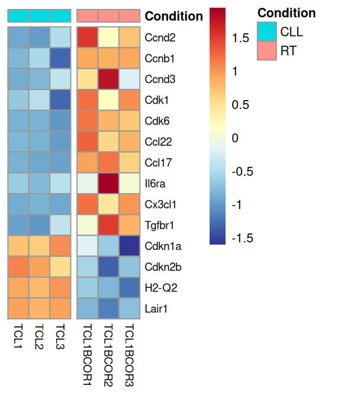

```r
# Subset zscore matrix
zscore_mat_interested <- zscore_mat_ordered[gene_id.lst, ]
rownames(zscore_mat_interested) <- names(gene_id.lst)

# Plot heatmap
pheatmap(
  zscore_mat_interested,
  cluster_rows = FALSE,
  cluster_cols = FALSE,
  show_rownames = TRUE,
  color = colorRampPalette(rev(brewer.pal(11, "RdYlBu")))(100),
  annotation_col = annotation_col_ordered,
  fontsize = 8,
  fontsize_row = 7,
  fontsize_col = 7,
  gaps_col = which(diff(as.numeric(factor(annotation_col_ordered$Condition))) != 0)
)
```

# Gene Set Enrichment Analysis (GSEA)

```r
# Import the related libraries in functional enrichment analysis
library(clusterProfiler)
library(enrichplot)
library(msigdbr)
library(org.Hs.eg.db)
```

```r
# Manipulate the expression data
dea <- human_res[!is.na(human_res$Gene.stable.ID), ]
lfc_vector <- dea$log2FoldChange # Create a named vector ranked based on the log2 fold change
names(lfc_vector) <- dea$Gene.stable.ID
lfc_vector <- na.omit(lfc_vector) # Omit any NA values
lfc_vector <- sort(lfc_vector, decreasing = TRUE) # Sort the log2 fold change in descending order
lfc_vector <- lfc_vector[!duplicated(names(lfc_vector))]
```

## Hallmark

```r
# Hallmark
HM_gsea <- HM_GSEA(lfc_vector, gene_ident = "ensembl_gene")

# Collect the HM GSEA result
HM_GSEA.result <- HM_gsea@result
HM_GSEA_selected.result <- HM_GSEA.result %>%
  as_tibble() %>%
  dplyr::select(c(Description, NES, pvalue, p.adjust))

DT::datatable(HM_GSEA_selected.result, options = list(scrollX = TRUE))
```

|  | Description | NES | pvalue | p.adjust |
| --- | --- | --- | --- | --- |
| 1 | HALLMARK_MYC_TARGETS_V1 | 2.230877053570758 | 2.39350140517454e-11 | 1.124945660432034e-09 |
| 2 | HALLMARK_E2F_TARGETS | 2.091343429494526 | 1.660167340401243e-09 | 3.901393249942922e-08 |
| 3 | HALLMARK_INFLAMMATORY_RESPONSE | -1.855830302122548 | 8.353287585355298e-06 | 0.0001280713856510145 |
| 4 | HALLMARK_G2M_CHECKPOINT | 1.799568676127545 | 1.089969239583102e-05 | 0.0001280713856510145 |
| 5 | HALLMARK_OXIDATIVE_PHOSPHORYLATION | 1.659157278843052 | 0.0001308241769861936 | 0.00122974726367022 |
| 6 | HALLMARK_IL6_JAK_STAT3_SIGNALING | -1.832449104648923 | 0.0002972939378436739 | 0.002328802513108779 |
| 7 | HALLMARK_INTERFERON_GAMMA_RESPONSE | -1.497883348772437 | 0.002759738170790115 | 0.01852967057530506 |
| 8 | HALLMARK_MTORC1_SIGNALING | 1.470647629269162 | 0.003891829399802266 | 0.02286449772383831 |
| 9 | HALLMARK_UV_RESPONSE_DN | 1.517435293331914 | 0.004667736755060371 | 0.02437595860975971 |
| 10 | HALLMARK_KRAS_SIGNALING_UP | -1.464457549049246 | 0.0068575412528875 | 0.03223044388857125 |

[output cut: 4 more lines]

We will explore the trends of hallmark terms reported from other single-cell pseudobulk studies such as Nadeu et al. (2022) and Hing et al (2023). From those studies, the terms such as E2F targets, Myc targets, and oxidative phosphorylation (OXPHOS) were upregulated.

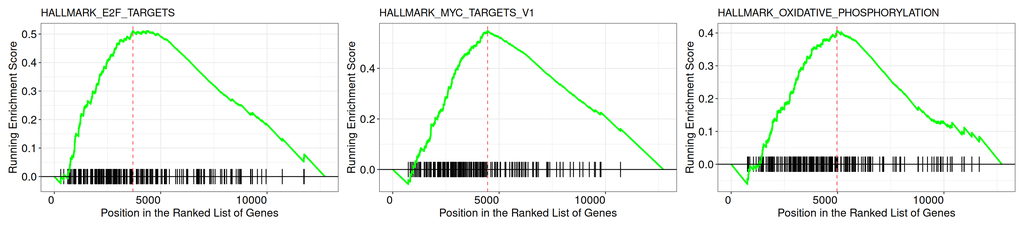

```r
# GSEA plot for HALLMARK_E2F_TARGETS, HALLMARK_MYC_TARGETS_V1, and HALLMARK_OXIDATIVE_PHOSPHORYLATION

E2F_gsea.plt <- gseaplot(HM_gsea,
                          by = "runningScore",
                          title = "HALLMARK_E2F_TARGETS",
                          geneSetID = "HALLMARK_E2F_TARGETS",
                          base_size = 10) +
  theme(axis.text.x = element_text(angle = 0, hjust = 1))

Myc_gsea.plt <- gseaplot(HM_gsea,
                          by = "runningScore",
                          title = "HALLMARK_MYC_TARGETS_V1",
                          geneSetID = "HALLMARK_MYC_TARGETS_V1",
                          base_size = 10) +
  theme(axis.text.x = element_text(angle = 0, hjust = 1))

OXPHOS_gsea.plt <- gseaplot(HM_gsea,
                          by = "runningScore",
                          title = "HALLMARK_OXIDATIVE_PHOSPHORYLATION",
                          geneSetID = "HALLMARK_OXIDATIVE_PHOSPHORYLATION",
                          base_size = 10) +
  theme(axis.text.x = element_text(angle = 0, hjust = 1))

E2F_gsea.plt + Myc_gsea.plt + OXPHOS_gsea.plt
```

## GO:BP

```r
# GO:BP
GOBP_gsea <- GO_GSEA(lfc_vector, gene_ident = "ensembl_gene")

# Collect the GSEA result
GOBP_GSEA.result <- GOBP_gsea@result
GOBP_GSEA_selected.result <- GOBP_GSEA.result %>%
  as_tibble() %>%
  dplyr::select(c(Description, NES, pvalue, p.adjust))

DT::datatable(GOBP_GSEA_selected.result, options = list(scrollX = TRUE))
```

|  | Description | NES | pvalue | p.adjust |
| --- | --- | --- | --- | --- |
| 1 | GOBP_ADAPTIVE_IMMUNE_RESPONSE | -2.46242942304314 | 7.159072843563191e-28 | 1.772586436066246e-24 |
| 2 | GOBP_PRODUCTION_OF_MOLECULAR_MEDIATOR_OF_IMMUNE_RESPONSE | -2.518537450213342 | 4.223933221647689e-21 | 5.229229328399839e-18 |
| 3 | GOBP_IMMUNOGLOBULIN_PRODUCTION | -2.463933451701132 | 1.665776692389688e-15 | 1.374821030118956e-12 |
| 4 | GOBP_LEUKOCYTE_MEDIATED_IMMUNITY | -2.038250895448188 | 8.814678611747952e-13 | 5.456286060671982e-10 |
| 5 | GOBP_LYMPHOCYTE_MEDIATED_IMMUNITY | -2.057948466971568 | 5.762364786113361e-11 | 2.853523042083336e-08 |
| 6 | GOBP_ADAPTIVE_IMMUNE_RESPONSE_BASED_ON_SOMATIC_RECOMBINATION_OF_IMMUNE_RECEPTORS_BUILT_FROM_IMMUNOGLOBULIN_SUPERFAMILY_DOMAINS | -2.005876462291616 | 1.749061896779158e-10 | 7.217795427375327e-08 |
| 7 | GOBP_DEFENSE_RESPONSE_TO_BACTERIUM | -2.149984224599237 | 5.103246499398975e-10 | 1.805091190358837e-07 |
| 8 | GOBP_REGULATION_OF_IMMUNE_EFFECTOR_PROCESS | -1.93870985952055 | 1.770700337992206e-09 | 4.871393374298557e-07 |
| 9 | GOBP_IMMUNE_RESPONSE_REGULATING_SIGNALING_PATHWAY | -1.798271836676123 | 1.629611177055101e-09 | 4.871393374298557e-07 |
| 10 | GOBP_B_CELL_MEDIATED_IMMUNITY | -2.114421016269695 | 7.291163965854957e-09 | 1.64117472540517e-06 |

[output cut: 117 more lines]

We will also explore the trends of GO:BP terms reported from other single-cell studies such as Nadeu et al. (2022) and Hing et al (2023). From those studies, the terms such as OXPHOS and mitochondrial translation were upregulated while BCR signalling was downregulated.

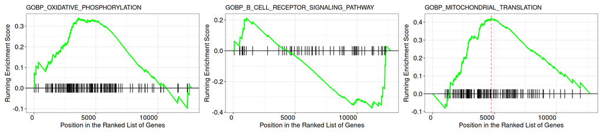

```r
# GSEA plot for GOBP_OXIDATIVE_PHOSPHORYLATION, GOBP_B_CELL_RECEPTOR_SIGNALING_PATHWAY, and GOBP_MITOCHONDRIAL_TRANSLATION

OXPHOS_GO_gsea.plt <- gseaplot(GOBP_gsea,
                          by = "runningScore",
                          title = "GOBP_OXIDATIVE_PHOSPHORYLATION",
                          geneSetID = "GOBP_OXIDATIVE_PHOSPHORYLATION",
                          base_size = 10) +
  theme(axis.text.x = element_text(angle = 0, hjust = 1))

BCR_GO_gsea.plt <- gseaplot(GOBP_gsea,
                          by = "runningScore",
                          title = "GOBP_B_CELL_RECEPTOR_SIGNALING_PATHWAY",
                          geneSetID = "GOBP_B_CELL_RECEPTOR_SIGNALING_PATHWAY",
                          base_size = 10) +
  theme(axis.text.x = element_text(angle = 0, hjust = 1))

mitochondrial_GO_gsea.plt <- gseaplot(GOBP_gsea,
                          by = "runningScore",
                          title = "GOBP_MITOCHONDRIAL_TRANSLATION",
                          geneSetID = "GOBP_MITOCHONDRIAL_TRANSLATION",
                          base_size = 10) +
  theme(axis.text.x = element_text(angle = 0, hjust = 1))

OXPHOS_GO_gsea.plt + BCR_GO_gsea.plt + mitochondrial_GO_gsea.plt
```

We also performed GSEA with additional enrichment systems such as KEGG pathways, Reactome, and WikiPath.

## KEGG pathway

```r
# KEGG pathway
KEGG_gsea <- KEGG_GSEA(lfc_vector, gene_ident = "ensembl_gene")

# Collect the HM GSEA result
KEGG_GSEA.result <- KEGG_gsea@result
KEGG_GSEA_selected.result <- KEGG_GSEA.result %>%
  as_tibble() %>%
  dplyr::select(c(Description, NES, pvalue, p.adjust))

DT::datatable(KEGG_GSEA_selected.result, options = list(scrollX = TRUE))
```

|  | Description | NES | pvalue | p.adjust |
| --- | --- | --- | --- | --- |
| 1 | KEGG_RIBOSOME | 1.980904003513775 | 3.817839077956406e-05 | 0.004734120456665943 |
| 2 | KEGG_DNA_REPLICATION | 1.963699971083988 | 0.0002950414360341354 | 0.01219504602274426 |
| 3 | KEGG_HEMATOPOIETIC_CELL_LINEAGE | -1.859189521168674 | 0.0002554211797675868 | 0.01219504602274426 |
| 4 | KEGG_CELL_CYCLE | 1.665687487544149 | 0.0007022172064896907 | 0.02176873340118041 |
| 5 | KEGG_TOLL_LIKE_RECEPTOR_SIGNALING_PATHWAY | -1.752209539377509 | 0.001038327864660225 | 0.02575053104357358 |

## Reactome

```r
# REACTOME
REACTOME_gsea <- REACTOME_GSEA(lfc_vector, gene_ident = "ensembl_gene")

# Collect the HM GSEA result
REACTOME_GSEA.result <- REACTOME_gsea@result
REACTOME_GSEA_selected.result <- REACTOME_GSEA.result %>%
  as_tibble() %>%
  dplyr::select(c(Description, NES, pvalue, p.adjust))

DT::datatable(REACTOME_GSEA_selected.result, options = list(scrollX = TRUE))
```

|  | Description | NES | pvalue | p.adjust |
| --- | --- | --- | --- | --- |
| 1 | REACTOME_SCAVENGING_OF_HEME_FROM_PLASMA | -2.506684817107952 | 5.966667769099344e-14 | 3.997667405296561e-11 |
| 2 | REACTOME_ROLE_OF_PHOSPHOLIPIDS_IN_PHAGOCYTOSIS | -2.503118705761376 | 1.411331449278339e-13 | 4.727960355082436e-11 |
| 3 | REACTOME_FCERI_MEDIATED_CA_2_MOBILIZATION | -2.45201287512617 | 1.362034920044337e-11 | 2.281408491074264e-09 |
| 4 | REACTOME_ROLE_OF_LAT2_NTAL_LAB_ON_CALCIUM_MOBILIZATION | -2.451454571959342 | 1.275721942663411e-11 | 2.281408491074264e-09 |
| 5 | REACTOME_ANTIGEN_ACTIVATES_B_CELL_RECEPTOR_BCR_LEADING_TO_GENERATION_OF_SECOND_MESSENGERS | -2.420955354858502 | 2.114280228346161e-11 | 2.833135505983856e-09 |
| 6 | REACTOME_TRANSLATION | 2.057303049163339 | 1.014177200558371e-10 | 1.132497873956847e-08 |
| 7 | REACTOME_CD22_MEDIATED_BCR_REGULATION | -2.369219199954621 | 2.783940424380216e-10 | 2.664628691906778e-08 |
| 8 | REACTOME_BINDING_AND_UPTAKE_OF_LIGANDS_BY_SCAVENGER_RECEPTORS | -2.373259412031252 | 3.921594359958797e-10 | 3.284335276465492e-08 |
| 9 | REACTOME_FCERI_MEDIATED_MAPK_ACTIVATION | -2.317954773451849 | 2.497645609633137e-09 | 1.859358398282446e-07 |
| 10 | REACTOME_CELL_SURFACE_INTERACTIONS_AT_THE_VASCULAR_WALL | -2.157346292944511 | 3.630286070308646e-09 | 2.432291667106793e-07 |

[output cut: 80 more lines]

## WikiPath

```r
# WikiPath
WIKIPATH_gsea <- WIKIPATH_GSEA(lfc_vector, gene_ident = "ensembl_gene")

# Collect the HM GSEA result
WIKIPATH_GSEA.result <- WIKIPATH_gsea@result
WIKIPATH_GSEA_selected.result <- WIKIPATH_GSEA.result %>%
  as_tibble() %>%
  dplyr::select(c(Description, NES, pvalue, p.adjust))

DT::datatable(WIKIPATH_GSEA_selected.result, options = list(scrollX = TRUE))
```

|  | Description | NES | pvalue | p.adjust |
| --- | --- | --- | --- | --- |
| 1 | WP_RETINOBLASTOMA_GENE_IN_CANCER | 1.937378185719046 | 1.725641408323084e-05 | 0.005867180788298487 |
| 2 | WP_NEURAL_CREST_CELL_MIGRATION_DURING_DEVELOPMENT | -1.975568216513669 | 3.923687600555959e-05 | 0.00667026892094513 |
| 3 | WP_CLEAR_CELL_RENAL_CELL_CARCINOMA_PATHWAYS | 1.860869006690098 | 0.0001370787674209688 | 0.01139424773643108 |
| 4 | WP_COMPLEMENT_SYSTEM | -1.83801737611124 | 0.0002010749600546661 | 0.01139424773643108 |
| 5 | WP_BURN_WOUND_HEALING | -1.828808648087606 | 0.0001131166339592509 | 0.01139424773643108 |
| 6 | WP_GENES_RELATED_TO_PRIMARY_CILIUM_DEVELOPMENT_BASED_ON_CRISPR | 1.785226725450158 | 0.0001896250023778829 | 0.01139424773643108 |
| 7 | WP_GPCRS_CLASS_A_RHODOPSINLIKE | -1.731144806839491 | 0.0003233894355323427 | 0.01570748686871378 |
| 8 | WP_NUCLEOTIDE_EXCISION_REPAIR_IN_XERODERMA_PIGMENTOSUM | 1.766451701200805 | 0.0005808480345478402 | 0.0219431479718073 |
| 9 | WP_MESODERMAL_COMMITMENT_PATHWAY | 1.707257390874192 | 0.0005243997101767377 | 0.0219431479718073 |
| 10 | WP_NEURAL_CREST_CELL_MIGRATION_IN_CANCER | -1.833404706620207 | 0.00084179978047143 | 0.02862119253602862 |

[output cut: 14 more lines]

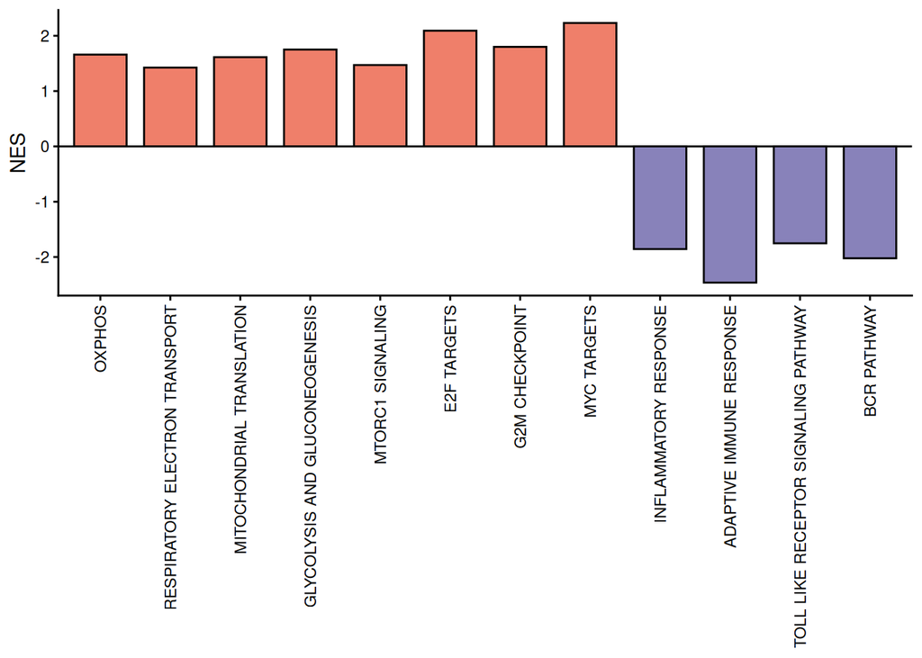

```r
# Bar plot of GSEA
gsea_bp <- rbind(HM_GSEA_selected.result[HM_GSEA_selected.result$Description == "HALLMARK_OXIDATIVE_PHOSPHORYLATION",],
                 REACTOME_GSEA_selected.result[REACTOME_GSEA_selected.result$Description ==
                                                 "REACTOME_AEROBIC_RESPIRATION_AND_RESPIRATORY_ELECTRON_TRANSPORT",],
                 GOBP_GSEA_selected.result[GOBP_GSEA_selected.result$Description == "GOBP_MITOCHONDRIAL_TRANSLATION",],
                 WIKIPATH_GSEA_selected.result[WIKIPATH_GSEA_selected.result$Description == "WP_GLYCOLYSIS_AND_GLUCONEOGENESIS",],
                 HM_GSEA_selected.result[HM_GSEA_selected.result$Description == "HALLMARK_MTORC1_SIGNALING",],
                 HM_GSEA_selected.result[HM_GSEA_selected.result$Description == "HALLMARK_E2F_TARGETS",],
                 HM_GSEA_selected.result[HM_GSEA_selected.result$Description == "HALLMARK_G2M_CHECKPOINT",],
                 HM_GSEA_selected.result[HM_GSEA_selected.result$Description == "HALLMARK_MYC_TARGETS_V1",],
                 HM_GSEA_selected.result[HM_GSEA_selected.result$Description == "HALLMARK_INFLAMMATORY_RESPONSE",],
                 GOBP_GSEA_selected.result[GOBP_GSEA_selected.result$Description == "GOBP_ADAPTIVE_IMMUNE_RESPONSE",],
                 KEGG_GSEA_selected.result[KEGG_GSEA_selected.result$Description == "KEGG_TOLL_LIKE_RECEPTOR_SIGNALING_PATHWAY",],
                 REACTOME_GSEA_selected.result[REACTOME_GSEA_selected.result$Description ==
                                                 "REACTOME_SIGNALING_BY_THE_B_CELL_RECEPTOR_BCR",]
                 )

gsea_bp$Description <- gsub("HALLMARK_", "", gsea_bp$Description)
gsea_bp$Description <- gsub("GOBP_", "", gsea_bp$Description)
gsea_bp$Description <- gsub("KEGG_", "", gsea_bp$Description)
gsea_bp$Description <- gsub("REACTOME_", "", gsea_bp$Description)
gsea_bp$Description <- gsub("WP_", "", gsea_bp$Description)
gsea_bp$Description <- gsub("_V1", "", gsea_bp$Description)
gsea_bp$Description <- gsub("OXIDATIVE_PHOSPHORYLATION", "OXPHOS", gsea_bp$Description)
gsea_bp$Description <- gsub("AEROBIC_RESPIRATION_AND_RESPIRATORY_ELECTRON_TRANSPORT", "RESPIRATORY_ELECTRON_TRANSPORT", gsea_bp$Description)
gsea_bp$Description <- gsub("SIGNALING_BY_THE_B_CELL_RECEPTOR_BCR", "BCR_PATHWAY", gsea_bp$Description)
gsea_bp$Description <- gsub("_V1", "", gsea_bp$Description)
gsea_bp$Description <- gsub("_", " ", gsea_bp$Description)

gsea_bp$Description <- factor(gsea_bp$Description, levels = gsea_bp$Description)
gsea_bp$Direction <- "Up"
gsea_bp$Direction[gsea_bp$NES<0] <- "Down"

gsea_bar.plt <- ggplot(gsea_bp, aes(x=Description, y=NES, fill=Direction)) +
  geom_bar(stat = "identity", color="black", width = 0.75) +
  theme_classic() +
  theme(axis.text.x = element_text(angle = 90, vjust = 0.5, hjust=1)) +
  geom_hline(yintercept = 0) +
  ylab("NES") + xlab(NULL) +
  scale_fill_manual(values=c("#8882BA", "#EF7F6A")) + theme(legend.position = "none")

gsea_bar.plt
```

```r
# Save gene expression and GSEA data
saveRDS(HM_gsea, path_to_save_hm_gsea)
saveRDS(GOBP_gsea, path_to_save_go_gsea)
saveRDS(KEGG_gsea, path_to_save_kegg_gsea)
saveRDS(REACTOME_gsea, path_to_save_reactome_gsea)
saveRDS(WIKIPATH_gsea, path_to_save_wikipath_gsea)
```